# Design Evaluation and Optimization in Continuous Space

# Scientific Background

This example is based on PK study of Remdesivir (Sukeishi et al. 2022). The PK is described by a 1-compartment model, with linear elimination, following an IV infusion.

**Considered original design.**

A single arm with 150 subjects received multiple IV doses: a loading dose of 400mg, then 200mg per day. Blood samples were collected at 6 time points: 1, 12, 24, 44, 72, and 120 h.

**Objectives**

1. Evaluation – Compute the Population, Individual and Bayesian Fisher Information Matrices (FIM) for the original design. Assess parameter precision (RSE%) and Shrinkage.
2. Optimization – Find the D-optimal design with only 4 sampling times, using possible sampling time windows and a continuous design space optimization. The number of subjects and the dosing regimen is unchanged.

# Design Evaluation

## Model Equations from from Library of Models

PFIM provides a library of pre-implemented standard PK/PD structural models. `modelFromLibrary` replaces `modelEquations` — the two arguments are mutually exclusive. The key `"PKModel"` is used for pharmacokinetic models.

The string `"Linear1InfusionSingleDose_ClV"` decodes as:

| Token | Meaning |
| --- | --- |
| `Linear` | First-order (linear) elimination |
| `1` | One-compartment disposition |
| `Infusion` | IV infusion route; requires `Tinf` in `Administration()` |
| `ClV` | Parameterised by clearance $Cl$ and volume $V$ |

The predicted concentration follows:

$$C_c(t) = \begin{cases}
\dfrac{D}{T_{inf} \cdot Cl}\!\left(1 - e^{-\frac{Cl}{V}t}\right) & 0
\leq t \leq T_{inf} \\[6pt]
C_c(T_{inf})\,e^{-\frac{Cl}{V}(t - T_{inf})} & t > T_{inf}
\end{cases}$$

```r
modelFromLibrary = list("PKModel" = "Linear1InfusionSingleDose_ClV")
```

## Model Parameters

The model has two structural parameters, both log-normally distributed:

| Parameter | Description | $\mu$ | $\omega$ | Fixed $\mu$ | Fixed $\omega$ |
| --- | --- | --- | --- | --- | --- |
| $V$ | Volume of distribution (L) | 50 | $\sqrt{0.26} \approx 0.51$ | No | No |
| $Cl$ | Elimination clearance (L/h) | 5 | $\sqrt{0.34} \approx 0.58$ | No | No |

```r
modelParameters = list(
  ModelParameter(name = "V",  distribution = LogNormal(mu = 50, omega = sqrt(0.26))),
  ModelParameter(name = "Cl", distribution = LogNormal(mu = 5,  omega = sqrt(0.34)))
)
```

## Residual Error Model

A `Combined1` error model is used for the PK response.

```r
errorModelRespPK = Combined1( output = "RespPK", sigmaInter = 0.5, sigmaSlope = sqrt( 0.15 ) )
modelError = list( errorModelRespPK )
```

## Administration Parameters

The dosing schedule encodes the full multiple-dose regimen. The loading dose (400 mg = 2× maintenance) rapidly raises $C_c$ toward the therapeutic target; subsequent 200 mg doses maintain near-steady-state concentrations.

```r
administrationRespPK = Administration(
  outcome  = "RespPK",
  Tinf     = rep(1, 5),           # 1-hour infusion for each of the 5 doses
  timeDose = seq(0, 96, 24),      # dosing at t = 0, 24, 48, 72, 96 h
  dose     = c(400, rep(200, 4))  # 400 mg loading + 4 × 200 mg maintenance
)
```

## Sampling Times

Six sampling times cover distinct phases of the multi-dose concentration profile:

| Time (h) | Pharmacokinetic phase |
| --- | --- |
| 1 | End of first infusion — $C_{max}$ of dose 1 |
| 12 | Mid-interdose Day 1 — early elimination |
| 24 | Trough before dose 2 — $C_{min}$ after dose 1 |
| 44 | Near $C_{min}$ of dose 2 (dose at 24 h + ~20 h) |
| 72 | Trough before dose 4 — approaching steady state |
| 120 | CTrough after last dose - at-Steady state |

```r
samplingTimesRespPK = SamplingTimes(
  outcome   = "RespPK",
  samplings = c(1, 12, 24, 44, 72, 120)
)
```

## Arm and Design

A single arm with all 150 subjects on the same regimen. No `initialCondition` is required: the library model sets $C_c(0) = 0$ internally for IV infusion models.

```r
arm1 = Arm(
  name            = "arm1",
  size            = 150,
  administrations = list(administrationRespPK),
  samplingTimes   = list(samplingTimesRespPK)
)

design1 = Design(name = "design1", arms = list(arm1))
```

## FIM Evaluation: Population, Individual, and Bayesian FIM

```r
# --- Population FIM ---
evaluationPop = Evaluation(
  name                = "evaluationPop",
  modelFromLibrary    = modelFromLibrary,
  modelParameters     = modelParameters,
  modelError          = modelError,
  outputs             = list("RespPK"),
  designs             = list(design1),
  fimType             = "population",
  odeSolverParameters = list(atol = 1e-8, rtol = 1e-8)
)
evaluationPopResults = run(evaluationPop)

# --- Individual FIM ---
evaluationInd = Evaluation(
  name                = "evaluationInd",
  modelFromLibrary    = modelFromLibrary,
  modelParameters     = modelParameters,
  modelError          = modelError,
  outputs             = list("RespPK"),
  designs             = list(design1),
  fimType             = "individual",
  odeSolverParameters = list(atol = 1e-8, rtol = 1e-8)
)
evaluationIndResults = run(evaluationInd)

# --- Bayesian FIM ---
evaluationBay = Evaluation(
  name                = "evaluationBay",
  modelFromLibrary    = modelFromLibrary,
  modelParameters     = modelParameters,
  modelError          = modelError,
  outputs             = list("RespPK"),
  designs             = list(design1),
  fimType             = "Bayesian",
  odeSolverParameters = list(atol = 1e-8, rtol = 1e-8)
)
evaluationBayResults = run(evaluationBay)
```

```r
show(evaluationPopResults)
```

```
 Population Fisher Matrix

                      μ_V       μ_Cl      ω²_V     ω²_Cl σ_inter_RespPK σ_slope_RespPK
μ_V             0.1393880 -0.2899109   0.00000   0.00000        0.00000         0.0000
μ_Cl           -0.2899109 14.3204999   0.00000   0.00000        0.00000         0.0000
ω²_V            0.0000000  0.0000000 404.77110  17.51007       51.06227       259.6216
ω²_Cl           0.0000000  0.0000000  17.51007 427.24316       54.71243        80.1080
σ_inter_RespPK  0.0000000  0.0000000  51.06227  54.71243     1982.21804      1361.3658
σ_slope_RespPK  0.0000000  0.0000000 259.62165  80.10800     1361.36582      1648.5030

 Fixed effects

            μ_V       μ_Cl
μ_V   0.1393880 -0.2899109
μ_Cl -0.2899109 14.3204999

 Variance components

                    ω²_V     ω²_Cl σ_inter_RespPK σ_slope_RespPK
ω²_V           404.77110  17.51007       51.06227       259.6216
ω²_Cl           17.51007 427.24316       54.71243        80.1080
σ_inter_RespPK  51.06227  54.71243     1982.21804      1361.3658
σ_slope_RespPK 259.62165  80.10800     1361.36582      1648.5030

 Determinant, condition numbers and D-criterion

Determinant: 380849659427.786
D-criterion: 85.1384217619946
Condition number of the fixed effects: 107.343235280232
Condition number of the random effects: 12.6420305367204

 Parameters estimation

               parametersValues         SE       RSE
μ_V                  50.0000000 2.73670901  5.473418
μ_Cl                  5.0000000 0.26999904  5.399981
ω²_V                  0.2600000 0.05481857 21.084067
ω²_Cl                 0.3400000 0.04861157 14.297522
σ_inter_RespPK        0.5000000 0.03570392  7.140784
σ_slope_RespPK        0.3872983 0.04131312 10.667003
```

```r
show(evaluationIndResults)
```

```
 Individual Fisher Matrix

                        μ_V        μ_Cl σ_inter_RespPK σ_slope_RespPK
μ_V             0.003831386 -0.03578704        0.00000        0.00000
μ_Cl           -0.035787035  0.74495930        0.00000        0.00000
σ_inter_RespPK  0.000000000  0.00000000       16.79391       12.15818
σ_slope_RespPK  0.000000000  0.00000000       12.15818       20.61786

 Fixed effects

              μ_V        μ_Cl
μ_V   0.003831386 -0.03578704
μ_Cl -0.035787035  0.74495930

 Variance components

               σ_inter_RespPK σ_slope_RespPK
σ_inter_RespPK       16.79391       12.15818
σ_slope_RespPK       12.15818       20.61786

 Determinant, condition numbers and D-criterion

Determinant: 0.312237623200518
D-criterion: 0.747517403243219
Condition number of the fixed effects: 354.325216014069
Condition number of the variance effects: 4.84715360183152

 Parameters estimation

               parametersValues         SE      RSE
μ_V                  50.0000000 21.7585945 43.51719
μ_Cl                  5.0000000  1.5604237 31.20847
σ_inter_RespPK        0.5000000  0.3223403 64.46806
σ_slope_RespPK        0.3872983  0.2909168 75.11439
```

```r
show(evaluationBayResults)
```

```
 Bayesian Fisher Matrix

           μ_V      μ_Cl
μ_V   9.580004 -8.946759
μ_Cl -8.946759 18.741630

 Fixed effects

           μ_V      μ_Cl
μ_V   9.580004 -8.946759
μ_Cl -8.946759 18.741630

 Determinant, condition numbers and D-criterion

Determinant: 99.5003949119652
D-criterion: 9.9749884667585
Condition number of the fixed effects: 5.89169416176677

 Shrinkage

      Shrinkage
μ_V  0.02897805
μ_Cl 1.13271843

 Parameters estimation

     parametersValues        SE       RSE
μ_V                50 0.4340015 0.8680031
μ_Cl                5 0.3102919 6.2058381
```

```r
cat("--- Fisher Information Matrix (population FIM) ---\n")
print(getFisherMatrix(evaluationPopResults))

cat("--- Correlation Matrix (population FIM) ---\n")
print(getCorrelationMatrix(evaluationPopResults))

cat("--- Standard Errors ---\n")
print(getSE(evaluationPopResults))

cat("--- Relative Standard Errors ---\n")
print(getRSE(evaluationPopResults))

cat("--- Shrinkage ---\n")
print(getShrinkage(evaluationPopResults))

cat("--- D-Criterion ---\n")
print(getDcriterion(evaluationPopResults))
```

[output not shown]

### Response profiles

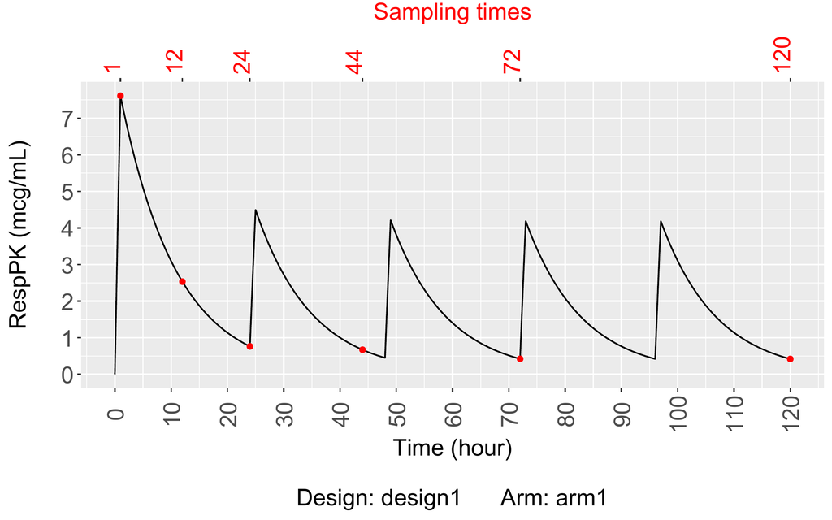

PK response profile – arm1 (population FIM)

```r
plotOptions = list(unitTime = "hour", unitOutcomes = "mcg/mL")
# plot() is the unified OO entry point -- dispatches on class, returns a named list:
#   $evaluation         -> nested [["design"]][["arm"]][["outcome"]]
#   $sensitivityIndices -> nested [["design"]][["arm"]][["outcome"]][["param"]]
#   $SE / $RSE          -> ggplot2 bar charts
# Predicted concentration profile with sampling times overlaid
plotsEval = plot(evaluationPopResults,
                 plotOptions = plotOptions,
                 which       = c("evaluation", "sensitivityIndices", "SE", "RSE"))
plotOutcomesRespPK = plotsEval$evaluation[["design1"]][["arm1"]][["RespPK"]]
print(plotOutcomesRespPK)
```

### Sensitivity indices

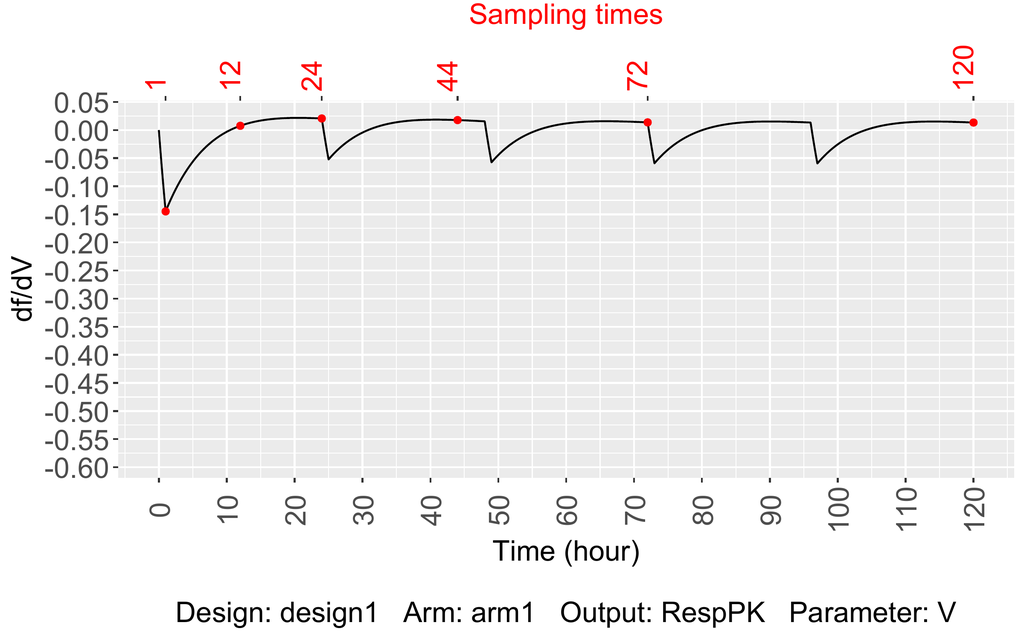

Sensitivity index for V – RespPK, arm1

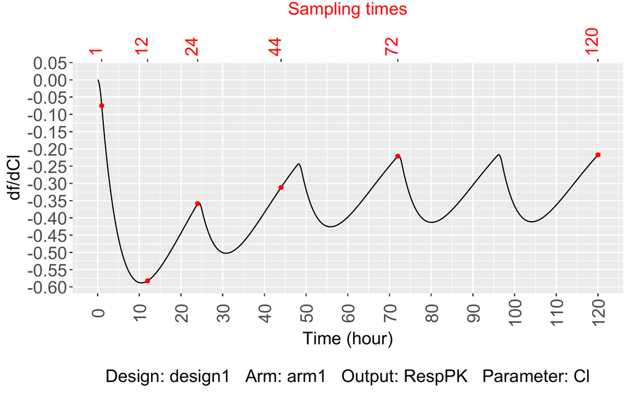

Sensitivity index for Cl – RespPK, arm1

```r
# $sensitivityIndices is computed in the same plot() call above
print(plotsEval$sensitivityIndices[["design1"]][["arm1"]][["RespPK"]][["V"]])
print(plotsEval$sensitivityIndices[["design1"]][["arm1"]][["RespPK"]][["Cl"]])
```

### Standard errors and Relative Standard errors

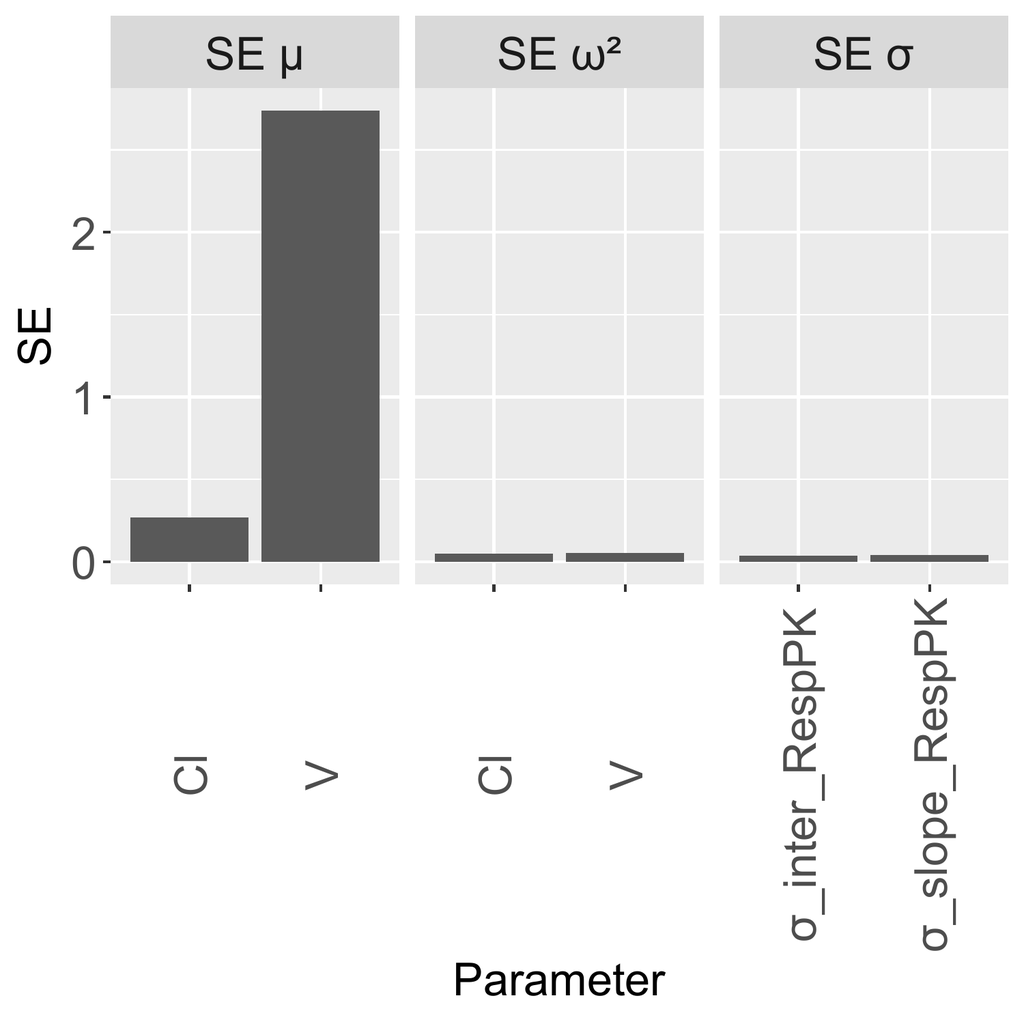

Standard Errors (SE)

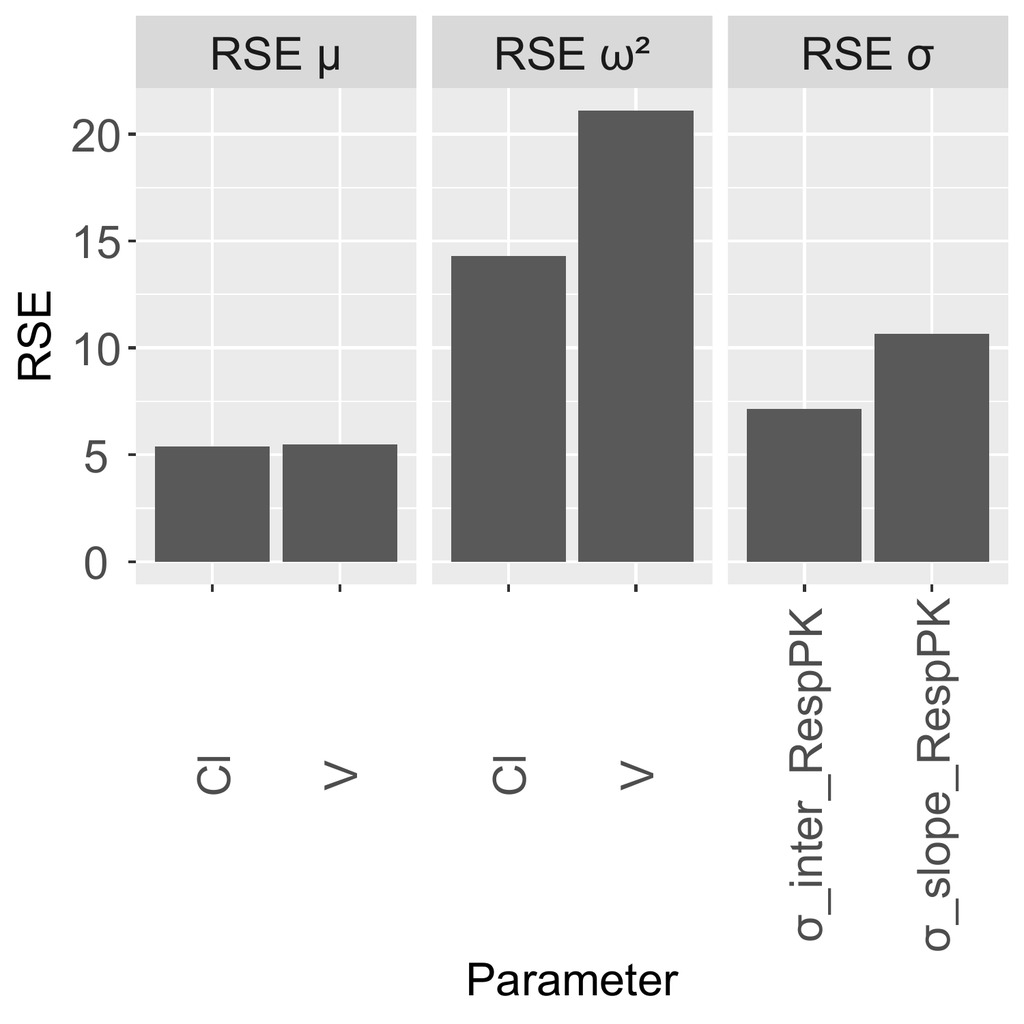

Relative Standard Errors (RSE)

```r
# Standard error and RSE bar charts -- computed in the same plot() call above
print(plotsEval$SE)
print(plotsEval$RSE)
```

# Design Optimization in Continuous Space

**Objective.** Find 4 optimal sampling times (instead of the original 6), constrained to two disjoint time windows, maximizing the D-criterion of the population FIM $M_{PF}$:

$$\max_{t_1,\ldots,t_4} \;
|M_{PF}(\xi)|^{1/P}
\quad \text{s.t.} \quad
t_1, t_2 \in [1,\,48], \quad t_3, t_4 \in [72,\,120], \quad |t_i - t_j|
\geq 5\,\text{h}$$

Three algorithms - PSO, PGBO, Simplex - are used.

## Shared Optimization Setup

```r
samplingTimesOptim = SamplingTimes(
  outcome   = "RespPK",
  samplings = c(1, 48, 72, 120)   # initial guess: window boundaries
)

samplingConstraintsRespPK = SamplingTimeConstraints(
  outcome                = "RespPK",
  initialSamplings       = c(1, 48, 72, 120),
  numberOfTimesByWindows = c(2, 2),
  samplingsWindows       = list(c(1,  48),    # Window 1: post-dose 1 to pre-dose 3
                                c(72, 120)),  # Window 2: near-SS to post-last-dose
  minSampling            = 5                  # min 5 h between consecutive samples
)

arm2 = Arm(
  name                     = "arm2",
  size                     = 150,
  administrations          = list(administrationRespPK),
  samplingTimes            = list(samplingTimesOptim),
  samplingTimesConstraints = list(samplingConstraintsRespPK)
)

# numberOfArms = 150: upper bound on distinct elementary protocols
design2 = Design(name = "design2", arms = list(arm2), numberOfArms = 150)
```

## PSO Algorithm (Particle Swarm Optimization)

```r
optimizationPSO = Optimization(
  name                = "PSO",
  modelFromLibrary    = modelFromLibrary,
  modelParameters     = modelParameters,
  modelError          = modelError,
  optimizer           = "PSOAlgorithm",
  optimizerParameters = list(
    maxIteration                = 100,
    populationSize              = 50,
    personalLearningCoefficient = 2.05,
    globalLearningCoefficient   = 2.05,
    seed                        = 42,
    showProcess                 = FALSE
  ),
  designs  = list(design2),
  fimType  = "population",
  outputs  = list("RespPK")
)
optimizationPSO = run(optimizationPSO)
```

```r
show(optimizationPSO)
```

```
=====================================
  Initial design
=====================================

  Arms name Number of subjects Outcome                    Dose   Sampling times
1      arm2                150  RespPK 400, 200, 200, 200, 200 (1, 48, 72, 120)

 Population Fisher Matrix

                      μ_V       μ_Cl      ω²_V     ω²_Cl σ_inter_RespPK σ_slope_RespPK
μ_V             0.1354839 -0.3248313   0.00000   0.00000        0.00000        0.00000
μ_Cl           -0.3248313 12.1107623   0.00000   0.00000        0.00000        0.00000
ω²_V            0.0000000  0.0000000 382.41404  21.98237       44.63647      264.88128
ω²_Cl           0.0000000  0.0000000  21.98237 305.56368      105.52177       79.50987
σ_inter_RespPK  0.0000000  0.0000000  44.63647 105.52177     1392.16105      653.06837
σ_slope_RespPK  0.0000000  0.0000000 264.88128  79.50987      653.06837      634.97897

 Fixed effects

            μ_V       μ_Cl
μ_V   0.1354839 -0.3248313
μ_Cl -0.3248313 12.1107623

 Variance components

                    ω²_V     ω²_Cl σ_inter_RespPK σ_slope_RespPK
ω²_V           382.41404  21.98237       44.63647      264.88128
ω²_Cl           21.98237 305.56368      105.52177       79.50987
σ_inter_RespPK  44.63647 105.52177     1392.16105      653.06837
σ_slope_RespPK 264.88128  79.50987      653.06837      634.97897

 Determinant, condition numbers and D-criterion

Determinant: 41386277548.9818
D-criterion: 58.8133694373923
Condition number of the fixed effects: 95.6713072499344
Condition number of the random effects: 18.4576745614613

 Parameters estimation

```

[output cut: 40 more lines]

```

Determinant: 207256273436.376
D-criterion: 76.9280305604956
Condition number of the fixed effects: 81.881392644448
Condition number of the random effects: 6.92393338504603

 Parameters estimation

               parametersValues         SE       RSE
μ_V                  50.0000000 2.55953621  5.119072
μ_Cl                  5.0000000 0.28542513  5.708503
ω²_V                  0.2600000 0.04654285 17.901095
ω²_Cl                 0.3400000 0.05674885 16.690838
σ_inter_RespPK        0.5000000 0.04739386  9.478773
σ_slope_RespPK        0.3872983 0.03156589  8.150277
```

## PGBO Algorithm (Population genetic-based optimization)

```r
optimizationPGBO = Optimization(
  name                = "PGBO",
  modelFromLibrary    = modelFromLibrary,
  modelParameters     = modelParameters,
  modelError          = modelError,
  optimizer           = "PGBOAlgorithm",
  optimizerParameters = list(
    N              = 30,
    muteEffect     = 0.65,
    maxIteration   = 1000,
    purgeIteration = 200,
    seed           = 42,
    showProcess    = FALSE
  ),
  designs  = list(design2),
  fimType  = "population",
  outputs  = list("RespPK")
)
optimizationPGBO = run(optimizationPGBO)
```

```r
show(optimizationPGBO)
```

```
=====================================
  Initial design
=====================================

  Arms name Number of subjects Outcome                    Dose   Sampling times
1      arm2                150  RespPK 400, 200, 200, 200, 200 (1, 48, 72, 120)

 Population Fisher Matrix

                      μ_V       μ_Cl      ω²_V     ω²_Cl σ_inter_RespPK σ_slope_RespPK
μ_V             0.1354839 -0.3248313   0.00000   0.00000        0.00000        0.00000
μ_Cl           -0.3248313 12.1107623   0.00000   0.00000        0.00000        0.00000
ω²_V            0.0000000  0.0000000 382.41404  21.98237       44.63647      264.88128
ω²_Cl           0.0000000  0.0000000  21.98237 305.56368      105.52177       79.50987
σ_inter_RespPK  0.0000000  0.0000000  44.63647 105.52177     1392.16105      653.06837
σ_slope_RespPK  0.0000000  0.0000000 264.88128  79.50987      653.06837      634.97897

 Fixed effects

            μ_V       μ_Cl
μ_V   0.1354839 -0.3248313
μ_Cl -0.3248313 12.1107623

 Variance components

                    ω²_V     ω²_Cl σ_inter_RespPK σ_slope_RespPK
ω²_V           382.41404  21.98237       44.63647      264.88128
ω²_Cl           21.98237 305.56368      105.52177       79.50987
σ_inter_RespPK  44.63647 105.52177     1392.16105      653.06837
σ_slope_RespPK 264.88128  79.50987      653.06837      634.97897

 Determinant, condition numbers and D-criterion

Determinant: 41386277548.9818
D-criterion: 58.8133694373923
Condition number of the fixed effects: 95.6713072499344
Condition number of the random effects: 18.4576745614613

 Parameters estimation

```

[output cut: 40 more lines]

```

Determinant: 190655846414.95
D-criterion: 75.8650394322679
Condition number of the fixed effects: 76.6486671491829
Condition number of the random effects: 7.78335282832985

 Parameters estimation

               parametersValues         SE       RSE
μ_V                  50.0000000 2.56116249  5.122325
μ_Cl                  5.0000000 0.29493763  5.898753
ω²_V                  0.2600000 0.04668595 17.956133
ω²_Cl                 0.3400000 0.06141230 18.062441
σ_inter_RespPK        0.5000000 0.04358091  8.716183
σ_slope_RespPK        0.3872983 0.03120088  8.056032
```

## Simplex Algorithm (Nelder-Mead)

```r
optimizationSimplex = Optimization(
  name                = "Simplex",
  modelFromLibrary    = modelFromLibrary,
  modelParameters     = modelParameters,
  modelError          = modelError,
  optimizer           = "SimplexAlgorithm",
  optimizerParameters = list(
    pctInitialSimplexBuilding = 10,
    maxIteration              = 1000,
    tolerance                 = 1e-10,
    showProcess               = FALSE
  ),
  designs  = list(design2),
  fimType  = "population",
  outputs  = list("RespPK")
)
optimizationSimplex = run(optimizationSimplex)
```

```r
show(optimizationSimplex)
```

```
=====================================
  Initial design
=====================================

  Arms name Number of subjects Outcome                    Dose   Sampling times
1      arm2                150  RespPK 400, 200, 200, 200, 200 (1, 48, 72, 120)

 Population Fisher Matrix

                      μ_V       μ_Cl      ω²_V     ω²_Cl σ_inter_RespPK σ_slope_RespPK
μ_V             0.1354839 -0.3248313   0.00000   0.00000        0.00000        0.00000
μ_Cl           -0.3248313 12.1107623   0.00000   0.00000        0.00000        0.00000
ω²_V            0.0000000  0.0000000 382.41404  21.98237       44.63647      264.88128
ω²_Cl           0.0000000  0.0000000  21.98237 305.56368      105.52177       79.50987
σ_inter_RespPK  0.0000000  0.0000000  44.63647 105.52177     1392.16105      653.06837
σ_slope_RespPK  0.0000000  0.0000000 264.88128  79.50987      653.06837      634.97897

 Fixed effects

            μ_V       μ_Cl
μ_V   0.1354839 -0.3248313
μ_Cl -0.3248313 12.1107623

 Variance components

                    ω²_V     ω²_Cl σ_inter_RespPK σ_slope_RespPK
ω²_V           382.41404  21.98237       44.63647      264.88128
ω²_Cl           21.98237 305.56368      105.52177       79.50987
σ_inter_RespPK  44.63647 105.52177     1392.16105      653.06837
σ_slope_RespPK 264.88128  79.50987      653.06837      634.97897

 Determinant, condition numbers and D-criterion

Determinant: 41386277548.9818
D-criterion: 58.8133694373923
Condition number of the fixed effects: 95.6713072499344
Condition number of the random effects: 18.4576745614613

 Parameters estimation

```

[output cut: 40 more lines]

```

Determinant: 57264569164.007
D-criterion: 62.0841871782222
Condition number of the fixed effects: 98.7579745041842
Condition number of the random effects: 13.8859868390161

 Parameters estimation

               parametersValues         SE       RSE
μ_V                  50.0000000 2.78175798  5.563516
μ_Cl                  5.0000000 0.28603036  5.720607
ω²_V                  0.2600000 0.06457386 24.836098
ω²_Cl                 0.3400000 0.05516612 16.225328
σ_inter_RespPK        0.5000000 0.05010192 10.020383
σ_slope_RespPK        0.3872983 0.06227156 16.078448
```

# References

Sukeishi, Asami, Kotaro Itohara, Atsushi Yonezawa, Yuki Sato, Katsuyuki Matsumura, Yoshiki Katada, Takayuki Nakagawa, et al. 2022. “Population Pharmacokinetic Modeling of GS-441524, the Active Metabolite of Remdesivir, in Japanese COVID-19 Patients with Renal Dysfunction.” *CPT: Pharmacometrics & Systems Pharmacology* 11 (1): 94–103.